# Roteiro de Projeto 🎞️

Prof. [Hélio Bomfim de Macêdo Filho](https://www.linkedin.com/in/heliomacedofilho/)  
[Mestrado em Administração Pública: Ciência de Dados e Inteligência Artificial no Setor Público](https://www.idp.edu.br/mestrado/profissional-em-ciencia-de-dados)

## Sumário (Aula 1 de 2)

- Cenário 🗺️
- Problema ‼️
- Medida de Desempenho 🚀
- Bisbilhotando os Dados 👀
- Segmentando Dados (em Treinamento 🏋️‍♂️ e em Teste 🧪)
- Visualização 🖼️
- Combinando Características/Variáveis
- Preparação dos Dados 🎲
- Limpeza 🧹
- Dados Textuais (e Categóricos) 💬
- Escala dos Dados 🧗🏾‍♀️
- Transformadores Customizados
- *Pipelines* 🪈
- Consolidando o Pré-Processamento 📦

## Sumário (Aula 2 de 2)

- Modelagem ⚙️
- Regressão Linear 📏
- Árvore de Decisão 🌴
- Agrupamento (*Ensemble*) 🌌
- Aperfeiçoamento ❤️‍🩹
- Busca em Grade
- Busca Aleatorizada
- Interprete Modelos e Erros
- Avalie seu Modelo
- Implantar 📦, Monitorar 🖥️ e Manter 🫡
- Salvar 💾
- Carregar 🔋

Principais passos de um projeto de aprendizado de máquina

1. Entenda o cenário;
2. Obtenha os dados;
3. Explore e visualize os dados para obter ideias;
4. Prepare os dados para os algoritmos de aprendizado de máquina;
5. Faça um ajuste fino do seu modelo;
6. Apresente sua solução;
7. Lance, monitore e mantenha seu sistema.

[figure not shown]

Para estudar Aprendizado de Máquina,

- Dados do mundo real ✅
- Dados artificiais ❌
  - (ainda que esse curso esteja repleto de dados artificiais.)

Há muitos locais com dados reais para explorar o mundo do aprendizado de máquina.

- Repositórios Populares de *open data*:
  - [OpenML, um Laboratório Mundial de Aprendizado de Máquina](https://openml.org/)
  - [Conjunto de dados no Kaggle](https://kaggle.com/datasets)
  - [PapersWithCode.com](https://paperswithcode.com/datasets)
  - [UC Irvine Machine Learning Repository](https://archive.ics.uci.edu/ml)
  - [Conjunto de Dados no AWS da Amazon](https://registry.opendata.aws/)
  - [Conjuntos de Dados no TensorFlow](https://tensorflow.org/datasets)
- Meta portais (eles listam repositórios *open data*):
  - [DataPortals.org](https://dataportals.org/)
  - [OpenDataMonitor.eu](https://opendatamonitor.eu/)
- Outras páginas que listam muitos repositórios populares de *open data*:
  - [Lista de conjuntos de dados de Aprendizado de Máquina do Wikipedia](https://en.wikipedia.org/wiki/List_of_datasets_for_machine-learning_research)
  - [Pergunta no Quora.com](https://www.quora.com/Where-can-I-find-large-datasets-open-to-the-public)
  - [Conjuntos de dados no Reddit](https://reddit.com/r/datasets)

## Cenário 🗺️

Vamos começar um projeto de Aprendizado de Máquina

[figure not shown]

Conjunto de dados:

- preços do setor imobiliário da Califórnia, baseado em um censo de 1990.
  - não são recentes 😔
  - mas têm muitas oportunidades de aprendizado 😁

👉 Leia sobre o conjunto de dados na fonte [original](https://github.com/ageron/handson-ml/tree/master/datasets/housing) ou [alternativa](https://www.kaggle.com/datasets/camnugent/california-housing-prices).

No [Kaggle](https://www.kaggle.com/datasets/camnugent/california-housing-prices), encontramos o seguinte dicionário de dados.

1. **longitude**: A measure of how far west a house is; a higher value is farther west;
2. **latitude**: A measure of how far north a house is; a higher value is farther north;
3. **housingMedianAge**: Median age of a house within a block; a lower number is a newer building;
4. **totalRooms**: Total number of rooms within a block;
5. **totalBedrooms**: Total number of bedrooms within a block;
6. **population**: Total number of people residing within a block;
7. **households**: Total number of households, a group of people residing within a home unit, for a block;
8. **medianIncome**: Median income for households within a block of houses (measured in tens of thousands of US Dollars);
9. **medianHouseValue**: Median house value for households within a block (measured in US Dollars);
10. **oceanProximity**: Location of the house w.r.t ocean/sea.

Vamos descarregar o conjunto de dados...

[figure not shown]

```python
import requests
from io import BytesIO

conteudo = requests.get("https://github.com/ageron/data/raw/main/housing.tgz",
                        stream=True)
conteudo = BytesIO(conteudo.content)
```

... extraí-los ...

```python
import tarfile

with tarfile.open(fileobj=conteudo) as tar:
    tar.extractall(path="data", filter='fully_trusted')
```

... e carregá-los.

```python
import pandas as pd

df = pd.read_csv("data/housing/housing.csv")
df.head()
```

|  | longitude | latitude | housing_median_age | total_rooms | total_bedrooms | population | households | median_income | median_house_value | ocean_proximity |
| --- | --- | --- | --- | --- | --- | --- | --- | --- | --- | --- |
| 0 | -122.23 | 37.88 | 41.0 | 880.0 | 129.0 | 322.0 | 126.0 | 8.3252 | 452600.0 | NEAR BAY |
| 1 | -122.22 | 37.86 | 21.0 | 7099.0 | 1106.0 | 2401.0 | 1138.0 | 8.3014 | 358500.0 | NEAR BAY |
| 2 | -122.24 | 37.85 | 52.0 | 1467.0 | 190.0 | 496.0 | 177.0 | 7.2574 | 352100.0 | NEAR BAY |
| 3 | -122.25 | 37.85 | 52.0 | 1274.0 | 235.0 | 558.0 | 219.0 | 5.6431 | 341300.0 | NEAR BAY |
| 4 | -122.25 | 37.85 | 52.0 | 1627.0 | 280.0 | 565.0 | 259.0 | 3.8462 | 342200.0 | NEAR BAY |

## Problema ‼️

Qual o objetivo?

- Uma previsão do preço médio do setor imobiliário no bairro,
- ainda que seja para alimentar um sistema de análise de investimento.

👉 Não é construir um modelo por si só.

[figure not shown]

Precisamos enquadrar o problema. O modelo será...

- Supervisionado, sem supervisão ou aprendizado por reforço?
- Será uma tarefa de classificação, de regressão ou outra coisa?
- Regressão univariada ou multivariada?
- Devemos utilizar técnicas de aprendizado em lote ou *online*?

**Resposta**

- **Supervisionado**: usamos exemplos rotulados, com o preço médio do setor imobiliário do bairro;
- **Regressão**: um valor (numérico) será previsto;
- **Multivariada**: utilizaremos múltiplas características/variáveis para fazer uma previsão;
- **Em lote**: o conjunto de dados é pequeno para caber em memória.

### Medida de Desempenho 🚀

Uma medida típica de desempenho para problemas de regressão:

- Raiz do Erro Quadrático Médio (RMSE, em inglês)
  - Ideia da quantidade de erros;
  - Penaliza grandes erros.

$$RMSE(X, h) = \sqrt{\frac{1}{m} \displaystyle\sum_{i=1}^{m} \left(h(x_i) - y_i\right)^2},$$

- $m$ é o número de instâncias/bairros;
- $x_i$ é o vetor de todos os valores das características/variáveis (do bairro $i$);
- $y_i$ é o rótulo (preço médio do bairro $i$);
- $h$ é a função de previsão do seu modelo, também chamada de hipótese; e

```python
m = df.shape[0]
m
```

```
20640
```

```python
x_i = df.iloc[0].drop('median_house_value')
x_i
```

```
longitude              -122.23
latitude                 37.88
housing_median_age        41.0
total_rooms              880.0
total_bedrooms           129.0
population               322.0
households               126.0
median_income           8.3252
ocean_proximity       NEAR BAY
Name: 0, dtype: object
```

```python
y_i = df[['median_house_value']].iloc[0]
y_i
```

```
median_house_value    452600.0
Name: 0, dtype: float64
```

- $X$ é a matriz que contém todos os valores das características/variáveis de todas as instâncias/bairros no conjunto de dados;

```python
X = df.drop(columns='median_house_value')
X.head()
```

|  | longitude | latitude | housing_median_age | total_rooms | total_bedrooms | population | households | median_income | ocean_proximity |
| --- | --- | --- | --- | --- | --- | --- | --- | --- | --- |
| 0 | -122.23 | 37.88 | 41.0 | 880.0 | 129.0 | 322.0 | 126.0 | 8.3252 | NEAR BAY |
| 1 | -122.22 | 37.86 | 21.0 | 7099.0 | 1106.0 | 2401.0 | 1138.0 | 8.3014 | NEAR BAY |
| 2 | -122.24 | 37.85 | 52.0 | 1467.0 | 190.0 | 496.0 | 177.0 | 7.2574 | NEAR BAY |
| 3 | -122.25 | 37.85 | 52.0 | 1274.0 | 235.0 | 558.0 | 219.0 | 5.6431 | NEAR BAY |
| 4 | -122.25 | 37.85 | 52.0 | 1627.0 | 280.0 | 565.0 | 259.0 | 3.8462 | NEAR BAY |

👉 Quanto tivermos um modelo de aprendizado de máquina $h$,

- será a função $$h.predict(x_i)$$

👉 $RMSE(X, h)$ é a função de custo medida no

- conjunto de exemplos $X$;
- utilizando sua hipótese $h$.

🚨 RMSE também é chamada de $L_2$,

- que aprendemos na Monitoria em Matemática e Probabilidade.

Alternativamente, poderíamos usar o Erro Absoluto Médio (MAE, em inglês):

$$MAE(X, h) = \frac{1}{m} \displaystyle\sum_{i=1}^{m} | h(x_i) - y_i|$$

👉 Veja que o MAE não penaliza grandes erros -- por ausência da potência $^2$ --,

- sendo útil na presença de valores discrepantes (*outliers*).

🚨 Ainda que o uso da medida de desempenho ocorra apenas na fase de modelagem

- é sempre bom saber qual a métrica que
- será utilizada para melhor endereçar o problema. 🚨

#### Extra 🗞️! + Medidas de Desempenho

O maior erro cometido pelo modelo ao realizar uma predição.

$$\max error(X, h) = \max_{i=1}^{m} | h(x_i) - y_i|$$

A proporção da variância nas variáveis dependentes

- que é explicada pelas variáveis independentes.

$$R^2 = 1 - \frac{\displaystyle\sum_{i=1}^m\left(h(x_i) - y_i\right)^2}{\displaystyle\sum_{i=1}^m\left(\bar{y} - y_i\right)^2}$$

👉 Use o **RMSE (Raiz do Erro Quadrático Médio)** quando

- Erros maiores devem ter um impacto desproporcionalmente maior,
  - portanto, precisam ser mais penalizados.
  - (e.g., ensaios clínicos,
    - em que um erro de $4 mg$
    - pode ser muito pior do que um erro de 2 mg).
- A unidade do erro é representada na unidade da variável-alvo.
  - 👆 mais interpretável
- Comparação da sensibilidade de diferentes modelos/métodos a erros grandes.

👉 Use o **MAE (Erro Absoluto Médio)** quando

- os erros devem ser penalizados proporcionalmente ao seu tamanho,
  - sem dar peso extra a erros maiores.
- (e.g. previsão do tempo,
  - em que um erro de 4 °C é simplesmente
  - duas vezes pior que um erro de 2 °C.)

👉 Use o **Erro Máximo (Max Error)** quando

- é importante limitar a magnitude dos erros,
  - garantindo que nenhuma previsão ultrapasse
  - um determinado limite crítico.
- (e.g., controle de temperatura de um equipamento
  - que não pode superaquecer mais do que 2 °C.)

👉 Use o **$R^2$ (Coeficiente de Determinação)** quando:

- a unidade do erro não é importante,
  - ou seja, o foco é na proporção da variância explicada pelo modelo.
- deseja-se comparar o desempenho do modelo
  - entre diferentes conjuntos de dados,
  - mesmo que tenham escalas ou unidades distintas.

#### Saiba Mais 👩‍🏫

```python
YouTubeVideo(id="v_ueBW_5dLg", width="100%")
```

[video not shown]

### Bisbilhotando os Dados 👀

[figure not shown]

Utilizando o método `head()` do DataFrame, vejamos as cinco linhas superiores

```python
df.head()
```

|  | longitude | latitude | housing_median_age | total_rooms | total_bedrooms | population | households | median_income | median_house_value | ocean_proximity |
| --- | --- | --- | --- | --- | --- | --- | --- | --- | --- | --- |
| 0 | -122.23 | 37.88 | 41.0 | 880.0 | 129.0 | 322.0 | 126.0 | 8.3252 | 452600.0 | NEAR BAY |
| 1 | -122.22 | 37.86 | 21.0 | 7099.0 | 1106.0 | 2401.0 | 1138.0 | 8.3014 | 358500.0 | NEAR BAY |
| 2 | -122.24 | 37.85 | 52.0 | 1467.0 | 190.0 | 496.0 | 177.0 | 7.2574 | 352100.0 | NEAR BAY |
| 3 | -122.25 | 37.85 | 52.0 | 1274.0 | 235.0 | 558.0 | 219.0 | 5.6431 | 341300.0 | NEAR BAY |
| 4 | -122.25 | 37.85 | 52.0 | 1627.0 | 280.0 | 565.0 | 259.0 | 3.8462 | 342200.0 | NEAR BAY |

O método `info()` é útil para a obtenção de uma rápida descrição dos dados,

- em especial
  - o número total de linhas;
  - o tipo de cada atributo; e
  - o número de valores não nulos.

```python
df.info()
```

```
<class 'pandas.DataFrame'>
RangeIndex: 20640 entries, 0 to 20639
Data columns (total 10 columns):
 #   Column              Non-Null Count  Dtype
---  ------              --------------  -----
 0   longitude           20640 non-null  float64
 1   latitude            20640 non-null  float64
 2   housing_median_age  20640 non-null  float64
 3   total_rooms         20640 non-null  float64
 4   total_bedrooms      20433 non-null  float64
 5   population          20640 non-null  float64
 6   households          20640 non-null  float64
 7   median_income       20640 non-null  float64
 8   median_house_value  20640 non-null  float64
 9   ocean_proximity     20640 non-null  str
dtypes: float64(9), str(1)
memory usage: 1.6 MB
```

👉 o atributo `total_bedrooms` tem apenas $20.433$ valores não nulos

- consequentemente, portanto, $20.640 - 20.433 = 207$ valores nulos.

Há um único atributo não-numérico: `ocean_proximity`.

👉 podemos descobrir

- quais categorias existem; e
- quantas instâncias/bairros pertencem a cada categoria,
  - utilizando o método `value_counts()`

```python
df["ocean_proximity"].value_counts()
```

```
ocean_proximity
<1H OCEAN     9136
INLAND        6551
NEAR OCEAN    2658
NEAR BAY      2290
ISLAND           5
Name: count, dtype: int64
```

O método `describe()` mostra um resumo (estatístico) dos atributos numéricos

```python
df.describe()
```

|  | longitude | latitude | housing_median_age | total_rooms | total_bedrooms | population | households | median_income | median_house_value |
| --- | --- | --- | --- | --- | --- | --- | --- | --- | --- |
| count | 20640.000000 | 20640.000000 | 20640.000000 | 20640.000000 | 20433.000000 | 20640.000000 | 20640.000000 | 20640.000000 | 20640.000000 |
| mean | -119.569704 | 35.631861 | 28.639486 | 2635.763081 | 537.870553 | 1425.476744 | 499.539680 | 3.870671 | 206855.816909 |
| std | 2.003532 | 2.135952 | 12.585558 | 2181.615252 | 421.385070 | 1132.462122 | 382.329753 | 1.899822 | 115395.615874 |
| min | -124.350000 | 32.540000 | 1.000000 | 2.000000 | 1.000000 | 3.000000 | 1.000000 | 0.499900 | 14999.000000 |
| 25% | -121.800000 | 33.930000 | 18.000000 | 1447.750000 | 296.000000 | 787.000000 | 280.000000 | 2.563400 | 119600.000000 |
| 50% | -118.490000 | 34.260000 | 29.000000 | 2127.000000 | 435.000000 | 1166.000000 | 409.000000 | 3.534800 | 179700.000000 |
| 75% | -118.010000 | 37.710000 | 37.000000 | 3148.000000 | 647.000000 | 1725.000000 | 605.000000 | 4.743250 | 264725.000000 |
| max | -114.310000 | 41.950000 | 52.000000 | 39320.000000 | 6445.000000 | 35682.000000 | 6082.000000 | 15.000100 | 500001.000000 |

Podemos traçar um histograma para cada atributo numérico com o método `hist()`

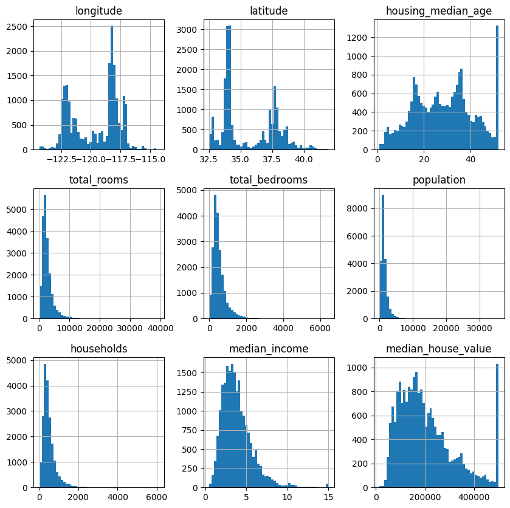

```python
df.hist(bins=50, figsize=(10, 10));
```

O que podemos perceber nas características/variáveis de...

- renda mediana; idade mediana; valor mediano com *traffic shapping*;
  - (`median_income`; `house_median_age`; `median_house_value`);
  - `median_house_value` tem um problema?
    - se sim, recoletar os dados das instâncias/bairros
      - com característica/variável alvo distorcido;
    - se não, remover essas instâncias/bairros do conjunto de dados.
- as escalas de todos os atributos variam;
- histogramas com caudas alongadas à direita;